# Bikeshare Visualization

Tyler Yankee

2022-10-26

```r
library(tidyverse)
library(here)
library(janitor)
library(lubridate)
library(data.table)

bikeshare = read_csv(here("data_raw", "202209-capitalbikeshare-tripdata.zip")) %>%
  clean_names()
```

```
Multiple files in zip: reading '202209-capitalbikeshare-tripdata.csv'
```

Haversine distance function:

```r
# This function takes five arguments:
#
# Longitude and latitude of the first location
# Longitude and latitude of the second location
# A parameter by which to round the responses
haversine <- function(long1, lat1, long2, lat2, round = 3) {
  # convert to radians
  long1 = long1 * pi / 180
  lat1  = lat1  * pi / 180
  long2 = long2 * pi / 180
  lat2  = lat2  * pi / 180

  R = 6371 # Earth mean radius in km

  a = sin((lat2 - lat1)/2)^2 + cos(lat1) * cos(lat2) * sin((long2 - long1)/2)^2
  d = R * 2 * asin(sqrt(a))

  return( round(d,round) ) # distance in km
}
```

## Do members typically ride longer/shorter/same amount than casual users?

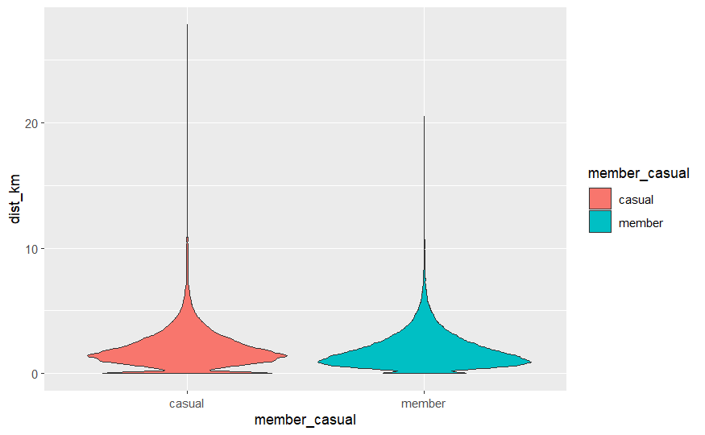

```r
# last filter is to remove one *extreme* outlier
bikeshare = bikeshare %>% mutate(dist_km = haversine(start_lng, start_lat, end_lng, end_lat)) %>% filter(dist_km < 7500)

bikeshare %>% ggplot(aes(x = member_casual, y = dist_km, fill = member_casual)) +
  geom_violin()
```

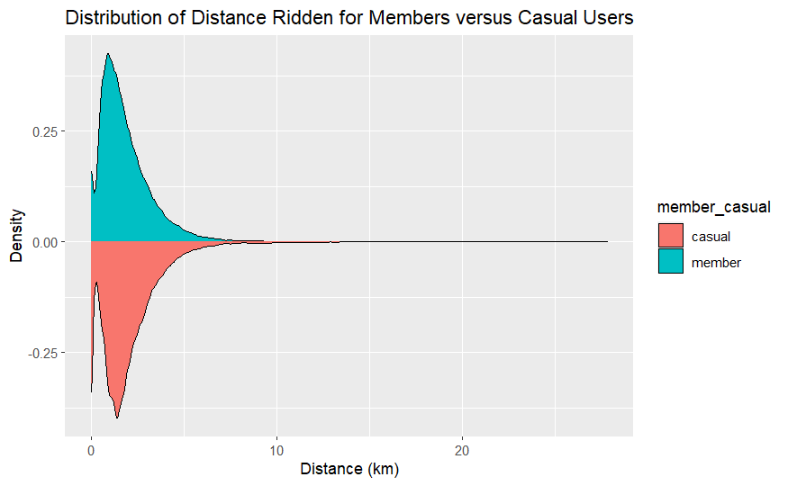

```r
bikeshare %>% ggplot(aes(x = dist_km, fill = member_casual)) +
  geom_density(aes(y = ..density..), data = ~ subset(., member_casual == "member")) +
  geom_density(aes(y = -..density..), data = ~ subset(., member_casual == "casual")) +
  ggtitle("Distribution of Distance Ridden for Members versus Casual Users") +
  xlab("Distance (km)") + ylab("Density")
```

The conclusion seems to be that there is no significant difference in ride distance between members and casual users.

```r
members = bikeshare %>% filter(member_casual == "member")
casual = bikeshare %>% filter(member_casual == "casual")

median(members$dist_km)
```

```
[1] 1.495
```

```r
median(casual$dist_km)
```

```
[1] 1.663
```

## Number of bikes out per hour on a given day

Looking at individual rides is nice, but not quite as useful for predicting how many bikes the company needs and where they need to put them (because one bike can have multiple riders on a given day, that’s kind of the whole point of the “share”).

For each minute of the day, count the number of rides that are happening at that minute (that is, that minute is between the start and end time for the ride). For now, just take September 1st. Later we can look at robustifying this to iterate over the days of the month.

```r
bikeshare_09_01 = bikeshare %>% filter(startsWith(as.character(started_at), "2022-09-01"))

times = c(seq(as.POSIXct("2022-09-01 00:00:00"),
              as.POSIXct("2022-09-01 23:59:00"), by=(60)))
nbikes = lapply(times, function(x)
  {
    nrow(bikeshare_09_01 %>% filter(x %within% interval(started_at, ended_at)))
  })
nbikes_09_01 = data.frame(unlist(times), unlist(nbikes)) %>%
  rename("time" = "unlist.times.", "nbikes" = "unlist.nbikes.")
```

Visualize this dataset

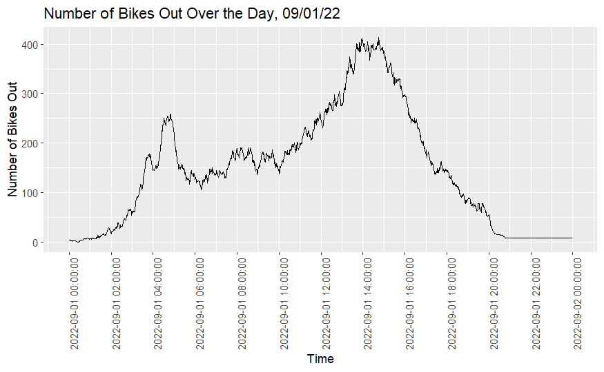

```r
nbikes_09_01 %>% ggplot(aes(x = time, y = nbikes)) + geom_line() +
  ggtitle("Number of Bikes Out Over the Day, 09/01/22") +
  xlab("Time") + ylab("Number of Bikes Out") +
  theme(axis.text.x=element_text(angle=90,hjust=1)) +
  scale_x_datetime(breaks = c(seq(as.POSIXct("2022-09-01 00:00:00"),
              as.POSIXct("2022-09-02 00:00:00"), by=(2*60*60))))
```

## New analysis (10/31) - duration

Visualization to determine if the duration of rides is different on different days of the week.

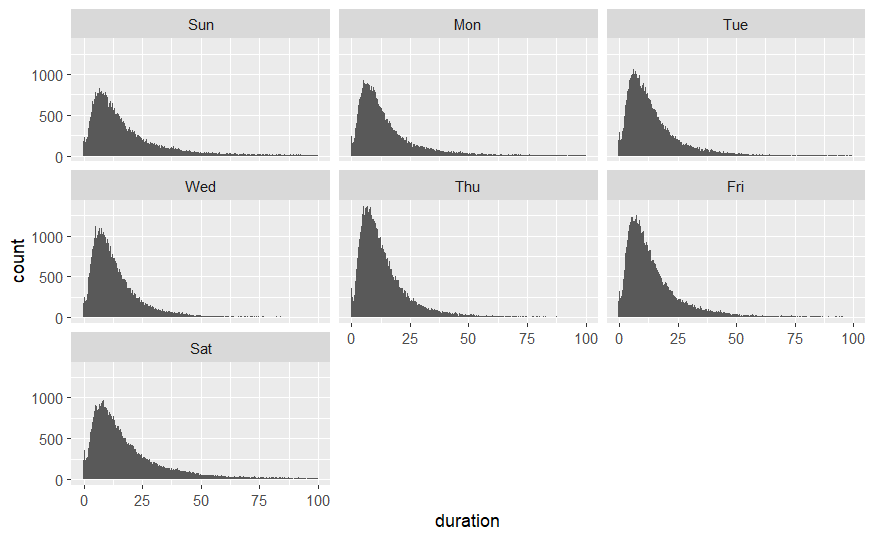

```r
bikeshare_dur = bikeshare %>% mutate(duration = as.numeric((ended_at - started_at) / 60),
                                     hour_of_day = hour(started_at),
                                     day_of_week = lubridate::wday(started_at, label = TRUE))
# There is data beyond 100 minutes, but it's so thin that it's not worth visualizing
bikeshare_dur %>% filter(duration < 100, duration >= 0) %>%
  ggplot(aes(x = duration)) + geom_histogram(bins = 300) + facet_wrap(~day_of_week)
```

## Cleaning

```r
bikeshare_dur = bikeshare_dur %>% filter(duration > 0)
```

## Riders vs time

Take a small sample from one day, just to develop the algorithm. Then it’s easier to generalize to larger dataset once developed.

pivot_longer makes the dataset “longer” on start and end time, then sort this result based on time

create increment variable, call start 1 and end -1, then cumsum(increment) = riders

uses a step plot to visualize the result

this is easy to generalize across the entire dataset, not just for one day

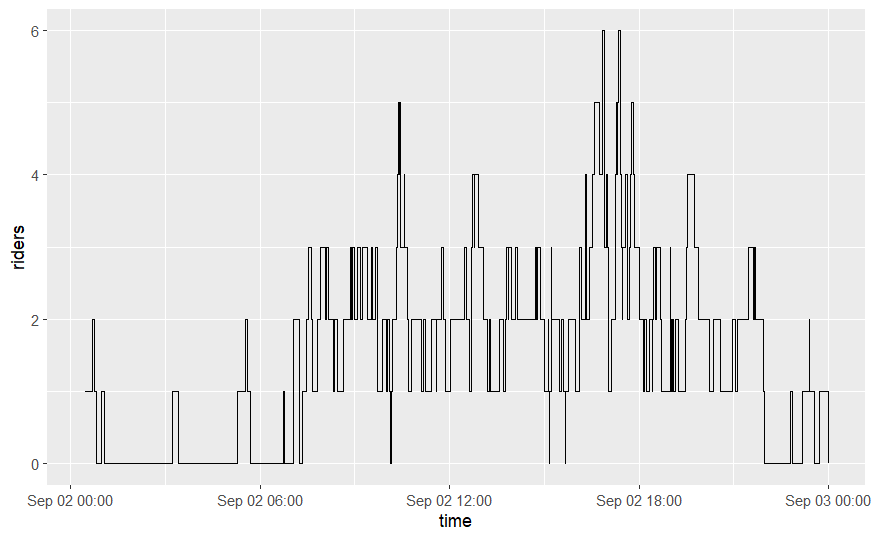

```r
bikeshare_09_02_s = bikeshare_dur %>% filter(mday(started_at) == 2) %>%
  slice_sample(n = 100) %>%
  select(started_at, ended_at) %>% rename("start" = "started_at", "end" = "ended_at")

bikeshare_09_02_s = bikeshare_09_02_s %>%
  pivot_longer(everything(), names_to = "type", values_to = "time") %>%
  arrange(time)

bikeshare_09_02_s = bikeshare_09_02_s %>% mutate(increment = case_when(
  type == "start" ~ 1,
  type == "end" ~ -1
), riders = cumsum(increment))

bikeshare_09_02_s %>% ggplot(aes(x = time, y = riders)) + geom_step()
```

## Formalize this approach

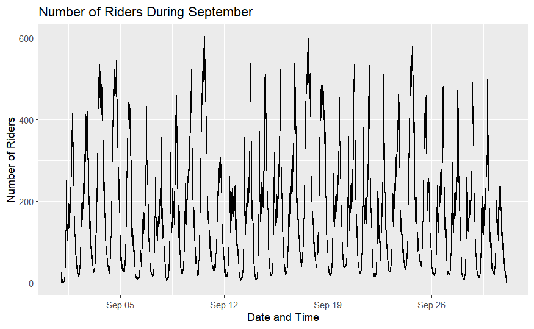

```r
riders = bikeshare_dur %>% select(started_at, ended_at) %>%
  filter(month(started_at) == 9, month(ended_at) == 9) %>%
  rename("start" = "started_at", "end" = "ended_at") %>%
  pivot_longer(everything(), names_to = "type", values_to = "time") %>%
  arrange(time) %>%
  mutate(increment = case_when(type == "start" ~ 1, type == "end" ~ -1),
         numriders = cumsum(increment))
riders %>% ggplot(aes(x = time, y = numriders)) + geom_line() +
  ggtitle("Number of Riders During September") +
  xlab("Date and Time") + ylab("Number of Riders")
```

We can apply some of the same manipulation and visualization techniques as we did above w/ duration.

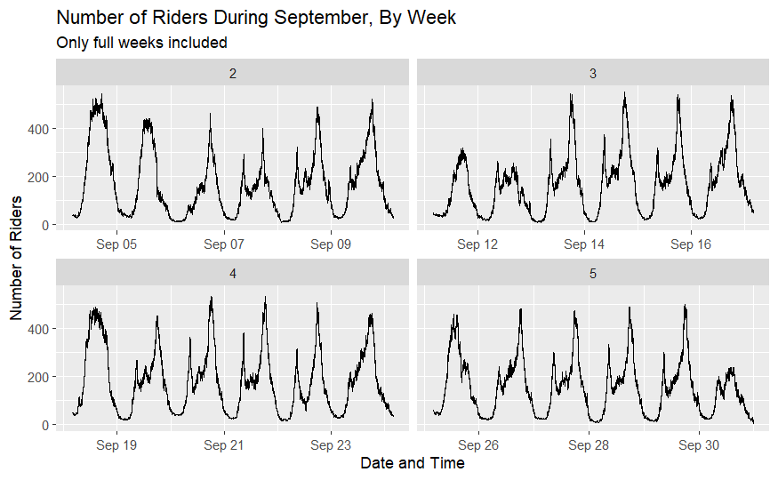

```r
riders = riders %>% mutate(week = case_when(
  time %within% interval(as.POSIXct("2022-09-04"), as.POSIXct("2022-09-10")) ~ 2,
  time %within% interval(as.POSIXct("2022-09-11"), as.POSIXct("2022-09-17")) ~ 3,
  time %within% interval(as.POSIXct("2022-09-18"), as.POSIXct("2022-09-24")) ~ 4,
  time %within% interval(as.POSIXct("2022-09-25"), as.POSIXct("2022-10-01")) ~ 5,
))
riders %>% filter(!is.na(week)) %>% ggplot(aes(x = time, y = numriders)) + geom_line() +
  facet_wrap(~week, scales = "free_x") +
  labs(title = "Number of Riders During September, By Week",
          subtitle = "Only full weeks included") +
  xlab("Date and Time") + ylab("Number of Riders")
```

Plot faceted by day

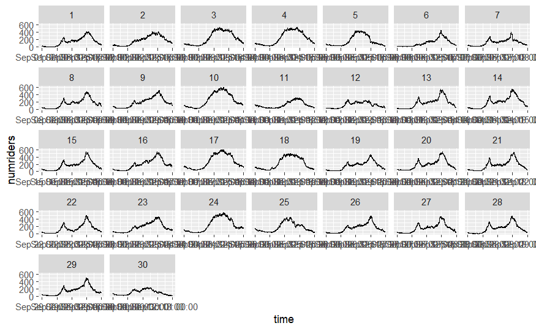

```r
riders %>% ggplot(aes(x = time, y = numriders)) + geom_step() +
  facet_wrap(~mday(time), scales = "free_x", ncol = 7)
```

For some reason my graph is messed up for a few of the days, I’ll have to figure that out later. Observations: - the days where there’s a dip in the morning and a peak in the afternoon are mostly weekends - exception to this is 9/5 which is a Monday, but also a holiday so that makes sense - pattern on Fridays is less bimodal (like the other weekdays) and more just a gradual increase - weather is a factor - ridership generally decreases - there was a storm in DC on 9/11 and 9/12, and rain in the evening on 9/30

## Separating by bike type

cumsum on bike type -include that variable in the dataset -group on that variable

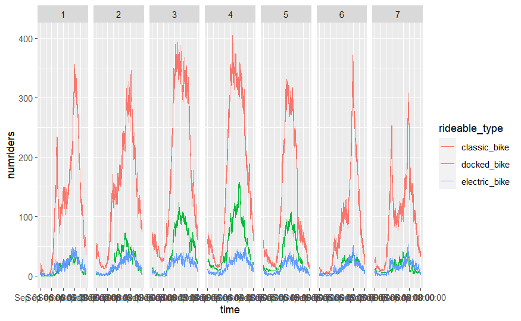

```r
bike_type = bikeshare %>% filter(month(started_at) == 9, month(ended_at) == 9) %>%
  select(rideable_type, started_at, ended_at) %>%
  rename("start" = "started_at", "end" = "ended_at") %>%
  pivot_longer(start:end, names_to = "type", values_to = "time") %>%
  arrange(time) %>%
  mutate(increment = case_when(
    type == "start" ~ 1,
    type == "end" ~ -1
  )) %>%
  group_by(rideable_type) %>%
  mutate(numriders = cumsum(increment)) %>%
  filter(mday(time) <= 7)
bike_type %>% ggplot(aes(x = time, y = numriders, color = rideable_type)) + geom_step() +
  facet_wrap(~mday(time), scales = "free_x", ncol = 7)
```

## Members vs. casual users

Now analyze members vs casual users in a similar way

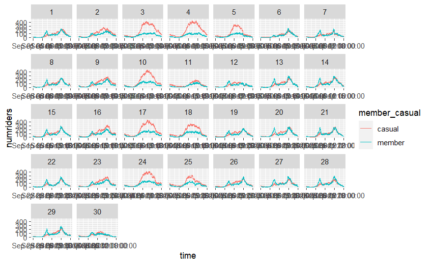

```r
members_casual = bikeshare %>% filter(month(started_at) == 9, month(ended_at) == 9) %>%
  select(member_casual, started_at, ended_at) %>%
  rename("start" = "started_at", "end" = "ended_at") %>%
  pivot_longer(start:end, names_to = "type", values_to = "time") %>%
  arrange(time) %>%
  mutate(increment = case_when(
    type == "start" ~ 1,
    type == "end" ~ -1
  )) %>%
  group_by(member_casual) %>%
  mutate(numriders = cumsum(increment))
members_casual %>% ggplot(aes(x = time, y = numriders, color = member_casual)) + geom_step() +
  facet_wrap(~mday(time), scales = "free_x", ncol = 7)
```

Observations: - on the weekdays, the morning commute time has more members than casual riders - on the weekends, the casual riders dominate (tourists, random people wanting to go for a bike ride?)

## Duration of bike rides over time

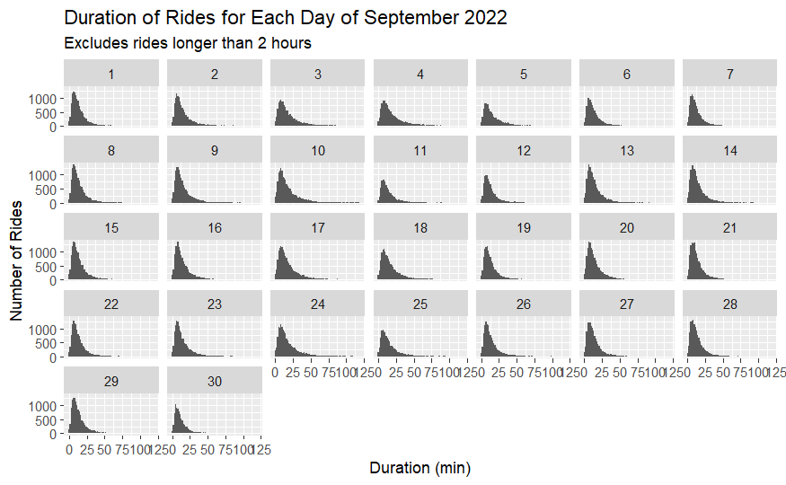

```r
# This filtering is done not only to remove the bad data (e.g. rides over 24 hours)
# but also because the distribution has such a strong right skew, narrowing down to this
# makes the patterns more visible
bikeshare_dur = bikeshare_dur %>% filter(duration < 120)

# day of the month
bikeshare_dur %>% ggplot(aes(x = duration)) + geom_histogram(bins = 75) +
  facet_wrap(~mday(started_at), ncol = 7) +
  labs(title = "Duration of Rides for Each Day of September 2022",
       subtitle = "Excludes rides longer than 2 hours") +
  xlab("Duration (min)") + ylab("Number of Rides")
```

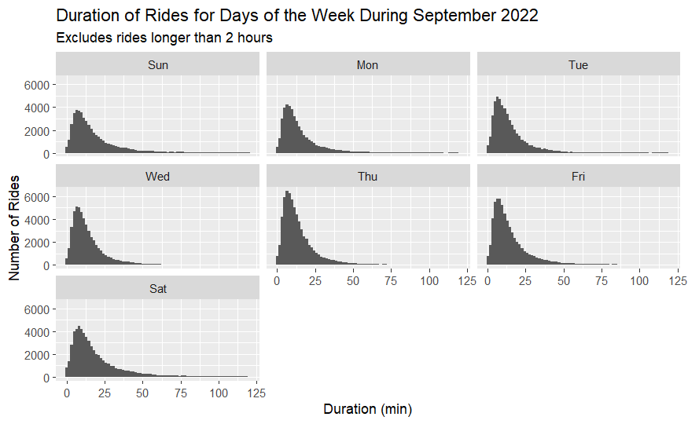

```r
# day of the week
bikeshare_dur %>% ggplot(aes(x = duration)) + geom_histogram(bins = 75) +
  facet_wrap(~day_of_week) +
  labs(title = "Duration of Rides for Days of the Week During September 2022",
       subtitle = "Excludes rides longer than 2 hours") +
  xlab("Duration (min)") + ylab("Number of Rides")
```

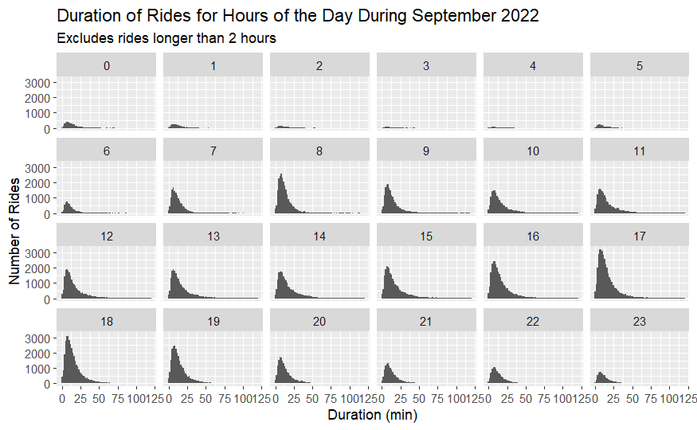

```r
# hour of the day
# technically, we need different viz to keep track of start and end times
# in practice these produce such similiar graphs that it's not very useful,
# so just take start time
bikeshare_dur %>% ggplot(aes(x = duration)) + geom_histogram(bins = 75) +
  facet_wrap(~hour_of_day, ncol=6) +
  labs(title = "Duration of Rides for Hours of the Day During September 2022",
       subtitle = "Excludes rides longer than 2 hours") +
  xlab("Duration (min)") + ylab("Number of Rides")
```

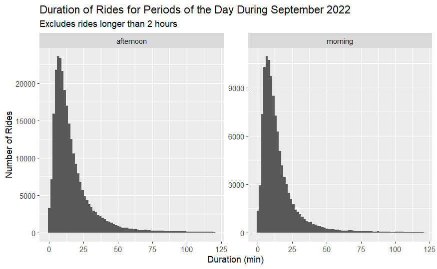

```r
# morning or afternoon?
bikeshare_dur = bikeshare_dur %>% mutate(period_of_day = case_when(
  am(started_at) ~ "morning",
  pm(started_at) ~ "afternoon"
))
bikeshare_dur %>% ggplot(aes(x = duration)) + geom_histogram(bins = 75) +
  facet_wrap(~period_of_day, scales = "free_y") +
  labs(title = "Duration of Rides for Periods of the Day During September 2022",
       subtitle = "Excludes rides longer than 2 hours") +
  xlab("Duration (min)") + ylab("Number of Rides")
```

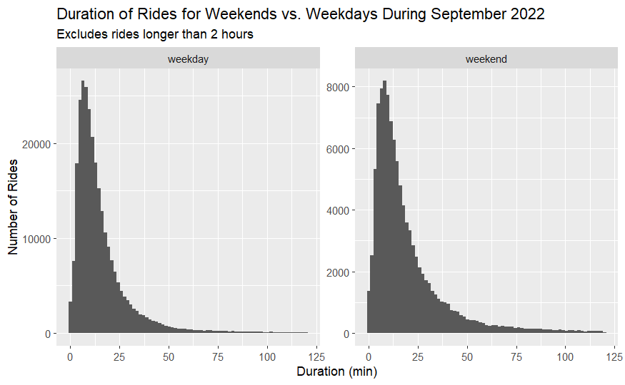

```r
# weekday or weekend?
bikeshare_dur = bikeshare_dur %>% mutate(day_type = case_when(
  day_of_week %in% c("Mon","Tue","Wed","Thu","Fri") ~ "weekday",
  day_of_week %in% c("Sat","Sun") ~ "weekend"
))
bikeshare_dur %>% ggplot(aes(x = duration)) + geom_histogram(bins = 75) +
  facet_wrap(~day_type, scales = "free_y") +
  labs(title = "Duration of Rides for Weekends vs. Weekdays During September 2022",
       subtitle = "Excludes rides longer than 2 hours") +
  xlab("Duration (min)") + ylab("Number of Rides")
```

## New direction

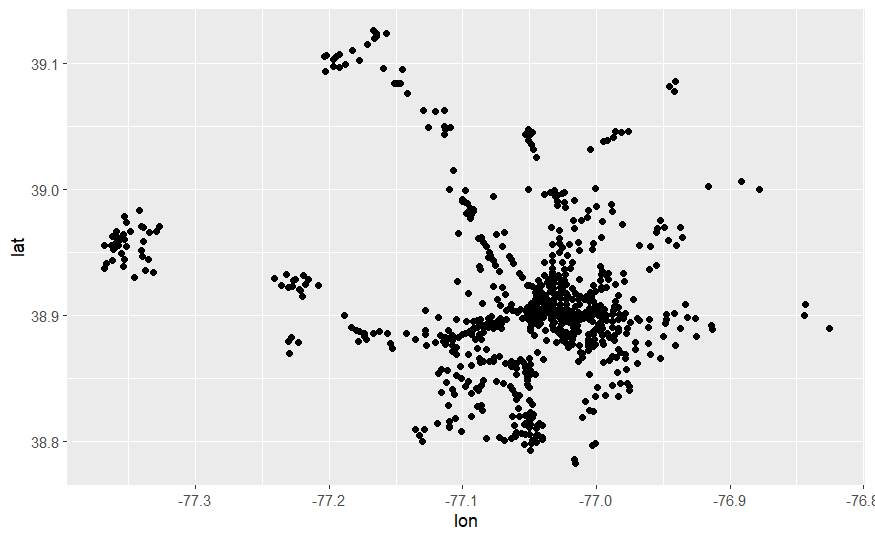

```r
library(gbfs)
dc_stations = get_station_information("https://gbfs.capitalbikeshare.com/gbfs/gbfs.json",
                                      output = "return") %>% clean_names()
dc_stations %>% ggplot(aes(x = lon, y = lat)) + geom_point()
```